# DSS R and Spark tutorial

Matthieu Brinkhuis

9/27/2018

# Introduction

In this tutorial, you will learn several things about the popular statistical program R http://www.r-project.com and about how to perform some simple statistical learning in R. In addition, we explore some of the machine learning possibilities of Spark. Note that in this manual, we use R both natively, and as a tool for communicating with Spark through the Sparkly package http://spark.rstudio.com.

## Learning objectives

By the end of this tutorial, you’ll be able to:

- Understand how data science in R and Spark are related
- Apply basic statistical learning techniques in Spark through R

If you already work with R, you can clearly skip the R introduction and move on to the examples with R and Spark.

## Setup

To work with R and Spark, you can use your (claimed) virtual machine. Untill this point, you have worked with the terminal, now we simple use Jupyter notebooks as interface.

Make sure your virtual machine is running, and access it through https://vmlabaXXX.westeurope.cloudapp.azure.com:8000/, replacing XXX by your virtual machine number. Login to the notebooks, and make sure you make a new file using the “New” and “R” buttons.

Use the “+” sign to add some text (formatted through Markdown), and you can add (R) code blocks too. Use the R command “sessionInfo()” and run it to see whether the installation is working.

# Working with R

## R references

There are many excellent tutorials to teach you R https://www.rstudio.com/online-learning/#r-programming, so just some simple references and tools are presented here. These are excellent (free) and extensive resources for learning R and statistical learning in R:

- An Introduction to Statistical Learning, by James et al. https://www-bcf.usc.edu/~gareth/ISL/
- R for Data Science, by Wicham et al. http://r4ds.had.co.nz

Since it is outside the scope of this course to deal with these books extensively, here are some light-weight suggestions too. You can use Swirl to learn R on your local machine using a dialogue in R itself, quite neat. You have to install R http://www.r-project.org and the interface RStudio http://www.rstudio.com. Type in the following commands and you enter an interactive tutor:

```r
install.packages("swirl")
library(swirl)
swirl()
```

For those that prefer an online course, Datacamp https://www.datacamp.com/courses/free-introduction-to-r offers a free R course.

From this tutorial you learn some basic R, depending on your background it might be sufficient by itself to finish this tutorial.

## R introduction

The following short introduction to R can be performed in the Jupyter notebook.

You can see R as an (extensive) calculator. For example, you can do the following:

```r
1+1
```

```
## [1] 2
```

where you can see the response immediately.

You can also perform more statistical operations, like drawing numbers from a (standard normal) distribution. For this, we use the function `rnorm()`, which you can recognize by the round braces `()`.

```r
rnorm(10)
```

```
##  [1]  0.6024989 -0.3984983 -0.9429964  2.4612701 -0.8633273  0.1354147
##  [7]  0.6852806 -0.5100281  1.3875529 -1.9879367
```

If you like to know more about a function, use the question mark `?rnorm()`.

Since there are many different functions, it is nice to use a cheat sheet as a reference, for example the “Base R” sheet at https://www.rstudio.com/resources/cheatsheets/.

You can store results for later use, for example for plotting. Use the assignment operater `<-` for this purpose, plotting a histogram is done by a plotting function (see the cheat sheet for this, or for advanced users: check out the excellent ggplot plotting framework).

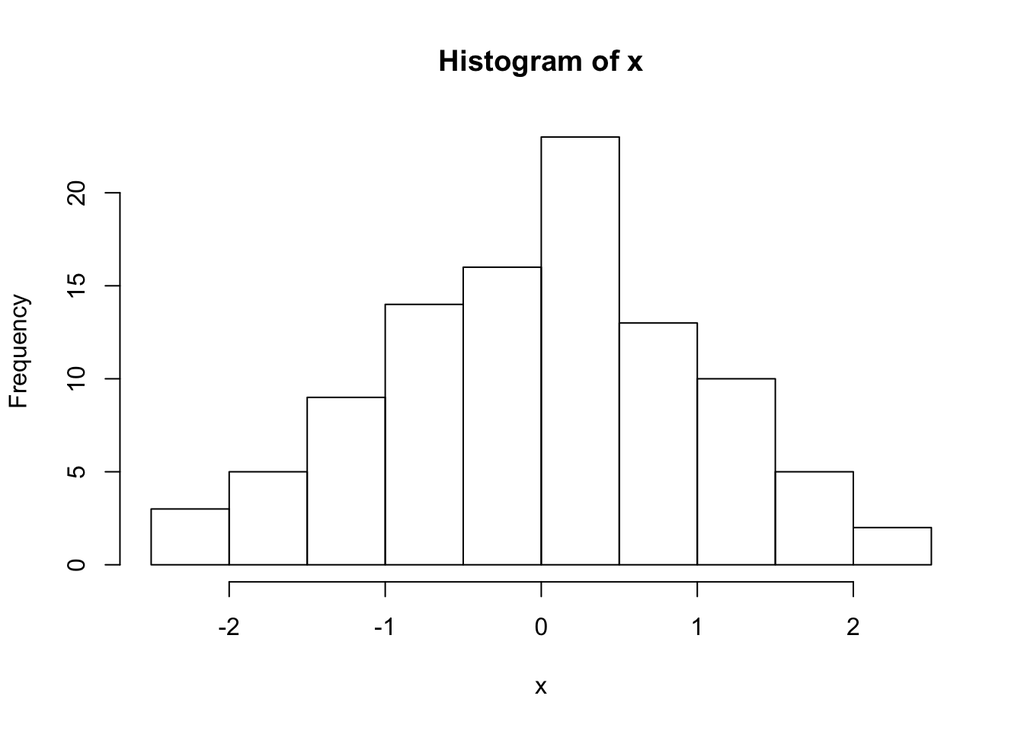

```r
x <- rnorm(100)
hist(x)
```

Now let’s look at some data. There are many example datasets available in R, you can see them by the `data()` function. Note that many extensions to R, called pacakges, bring their own datasets and functions. Note that packages can be found on The Comprehensive R Archive Network (CRAN) https://cran.r-project.org/ (but also on Github), and installed through the `install.packages()` function.

Let’s install a new packages using `install.packages()` to get some interesting data, and load it using:

```r
library(nycflights13)
```

The `nycflights13` package is airline on-time data for all flights departing NYC in 2013, including data on airlines, airports, weather, and planes, with the following tables:

- airlines: Airline names
- airports: Airport metadata
- flights: Flights data
- planes: Plane metadata
- weather: Hourly weather data

View the top of a table with the `head()` function:

```r
head(airports)
```

```
## # A tibble: 6 x 8
##   faa   name                      lat   lon   alt    tz dst   tzone
##   <chr> <chr>                   <dbl> <dbl> <int> <dbl> <chr> <chr>
## 1 04G   Lansdowne Airport        41.1 -80.6  1044    -5 A     America/New…
## 2 06A   Moton Field Municipal …  32.5 -85.7   264    -6 A     America/Chi…
## 3 06C   Schaumburg Regional      42.0 -88.1   801    -6 A     America/Chi…
## 4 06N   Randall Airport          41.4 -74.4   523    -5 A     America/New…
## 5 09J   Jekyll Island Airport    31.1 -81.4    11    -5 A     America/New…
## 6 0A9   Elizabethton Municipal…  36.4 -82.2  1593    -5 A     America/New…
```

Note that in Jupyter the output looks a bit different, since it nicely formats your R output. For a discription of the table, you can clearly use `?airports`.

In base R, you can select data using square brackets `[,]`, where before the `,` we select rows, and after the `,` columns. For example, we look at the `flights` table, we can select a single column and all rows using `flights[,'month']`. If we want a table to look at flight frequency over months, you can simply use:

```r
table(flights[,'month'])
```

```
##
##     1     2     3     4     5     6     7     8     9    10    11    12
## 27004 24951 28834 28330 28796 28243 29425 29327 27574 28889 27268 28135
```

Without going into detail on this data set, you can look at other tables, make plots, produce tables like we just did, etc. In addition, you can imagine more substantive analyses could be performed, like investigating the relation between departure time and delay. A simple start would be a correlation using `cor()`, where the help shows you how to deal with the missing observations. The correlation seems to be about $\rho=.28$.

For more R data analysis, browse for example through the books suggested above.

## R and dplyr

In R there are many ways to do data analysis. An especially easy way to do your “data wrangling” is by using the so-called Tidyverse https://tidyverse.org, `install.packages("tidyverse")`. On this website, you can also find many good tips for learning R and the Tidyverse.

Tidy data is referred to as data shaped such that each variable is in its own column, and each observation, or case, is in its own row. Get the cheat sheets on Data Import and Data Transformation on https://www.rstudio.com/resources/cheatsheets/ and study them. In this material, you encounter `dplyr`, which is not only a function, but a grammar of data manipulation. Once you have learned it, you can write very compact, readable syntax that does all of the boring transformation work. Don’t expect to learn it all in this tutorial, but make sure you familiarize yourself with it.

Here follows an example on the “flights” data discussed before. There is a nice and short tutorial on `dplyr` using this data on https://dplyr.tidyverse.org/articles/dplyr.html, we highlight one of their examples for you to follow:

For example, we could use these to find the number of planes and the number of flights that go to each possible destination:

```r
library(tidyverse)
destinations <- group_by(flights, dest)
summarise(destinations,
  planes = n_distinct(tailnum),
  flights = n()
)
```

```
## # A tibble: 105 x 3
##    dest  planes flights
##    <chr>  <int>   <int>
##  1 ABQ      108     254
##  2 ACK       58     265
##  3 ALB      172     439
##  4 ANC        6       8
##  5 ATL     1180   17215
##  6 AUS      993    2439
##  7 AVL      159     275
##  8 BDL      186     443
##  9 BGR       46     375
## 10 BHM       45     297
## # ... with 95 more rows
```

We can use these functions as a grammer, by using pipes `%>%`, which simply puts the output of one function in the next. So long lists of `dplyr` functions with temporariy variables, etc., can easily be read as follows:

```r
library(nycflights13)
group_by(flights, dest) %>%
  summarise(planes = n_distinct(tailnum),
            flights = n()) %>%
  mutate(fl_per_plane = flights / planes)
```

```
## # A tibble: 105 x 4
##    dest  planes flights fl_per_plane
##    <chr>  <int>   <int>        <dbl>
##  1 ABQ      108     254         2.35
##  2 ACK       58     265         4.57
##  3 ALB      172     439         2.55
##  4 ANC        6       8         1.33
##  5 ATL     1180   17215        14.6
##  6 AUS      993    2439         2.46
##  7 AVL      159     275         1.73
##  8 BDL      186     443         2.38
##  9 BGR       46     375         8.15
## 10 BHM       45     297         6.6
## # ... with 95 more rows
```

Make sure you can read this syntax, use the cheatsheets to understand the functions, and make sure you get what the `%>%` operator does.

Out of scope for this tutorial, but it is good to know that fancy graphics can be created with a similar grammar, using the `ggplot2` package. Surely, there is also a cheat sheet available, here a small example using the data above:

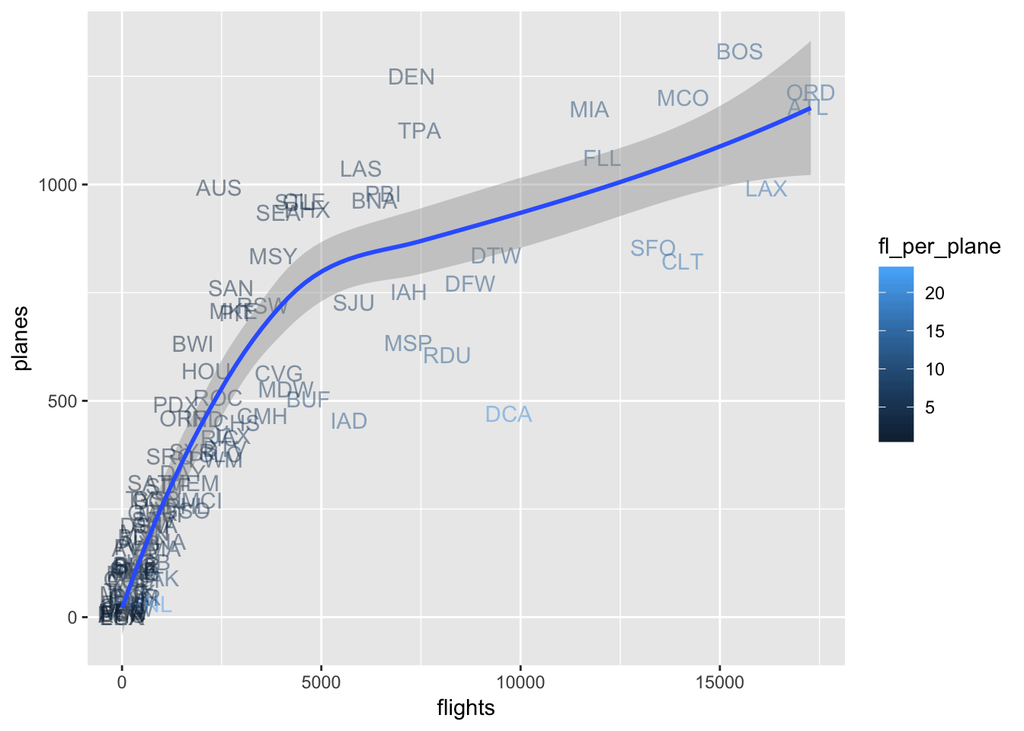

```r
group_by(flights, dest) %>%
  summarise(planes = n_distinct(tailnum),
            flights = n()) %>%
    mutate(fl_per_plane = flights / planes) %>%
  ggplot(aes(flights, planes, fl_per_plane)) +
  geom_text(aes(label = dest,
                color = fl_per_plane),
            alpha = .5) +
  geom_smooth()
```

# Using R and Spark

To use R and Spark, we will make use of a package called `sparklyr`. Please visit http://spark.rstudio.com and read the material. Make sure you get the cheat sheet too. Follow the first part of the tutorial including *Installation*, *Connecting to Spark* and *Using dplyr*. You will see many familiar concepts, including `dplyr`, the `nycflights13` package, and `ggplot`.

This syntax you have already performed:

```r
library(sparklyr)
spark_install(version = "2.1.0")
sc <- spark_connect(master = "local")
```

Here we load the flights data again, and remove the missings (just for the ease of illustration, don’t do this normally):

```r
flights = na.omit(flights)
flights_tbl <- copy_to(sc, flights, "flights", overwrite = TRUE)
```

You should understand by now that we now have two data objects with the flights table, `flights` and `flights_tbl`. The first resides in R, the second in Spark. Hereafter, we will perform some analyses in both R and Spark to compare the two.

## Regression

Regression in R and Spark:

```r
m <- lm(data = flights,
        arr_delay ~ dep_delay + air_time )

n <- ml_linear_regression(flights_tbl,
                          arr_delay ~ dep_delay + air_time)
```

If we look at the output of these two models, $m$ and $n$, we see similar coefficients:

```r
print(rbind(base_r=m$coefficients,spark_r=n$coefficients))
```

```
##         (Intercept) dep_delay   air_time
## base_r    -4.831805  1.018723 -0.0070547
## spark_r   -4.831805  1.018723 -0.0070547
```

Use the `summary()` function on these objects to look at how well they fit. To deal with how to evaluate models (e.g., training, validating, etc.) is beyond the scope of this tutorial.

Plotting multiple regression is not as intuitive as plotting a model with just one predictor, you can try to make a new model with a single predictor, and use `ggplot()` to make a plot, with a prediction line through it. While `ggplot` can make it’s own smooth lines, you can also add a `geom_abline` with the coefficients (interdept and slope) of your regression model. Advanced stuff would be plotting residuals, etc.

## K-means

K-means clustering is an easy clustering method. Feel free to use Wikipedia if you are not familiar with the method, here we demonstrate how to use and plot it, both using R and Spark on the same dataset.

You might for instance be be interested in looking whether you can find groups in departure time and scheduled departe time. Since there are just two variables involved in this, not very realistic, example, you can plot the results. However, please don’t just do something like `plot(x=flights$dep_time,y=flights$sched_dep_time)` or the `ggplot` alternative, since all (!) points will be used in the graph. Using simple sampling, or for some graphs even simple aggregates using for example `dplyr`, you can reduce the number of points.

Hereby a toy example, where we perform k-means clustering with 2 simple clusters:

```r
km2=ml_kmeans(flights_tbl, k=2,
              features = c("dep_delay", "air_time"))
```

Which can be plotted, we use a sample of 1000 points:

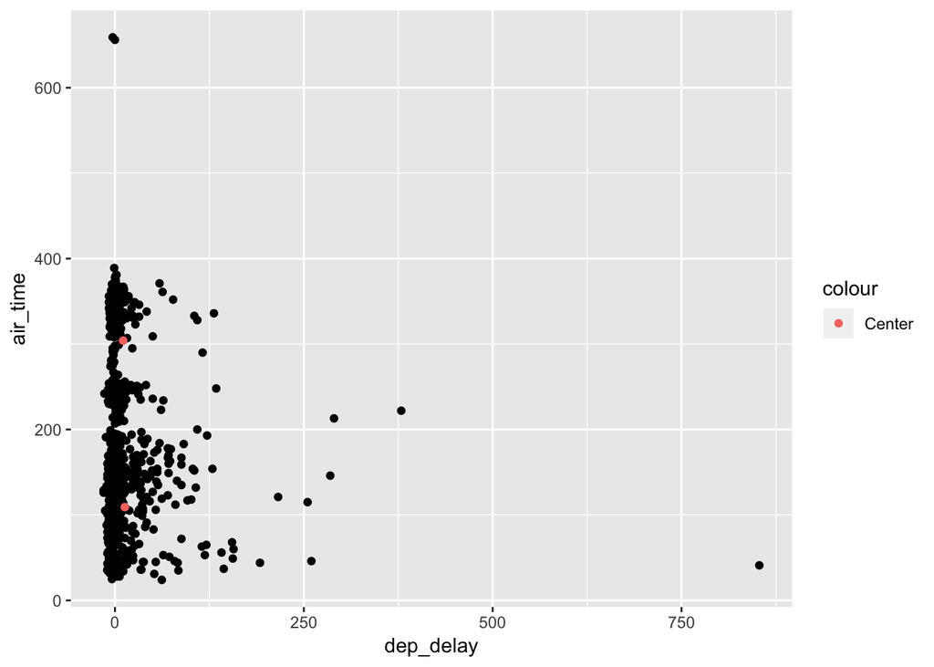

```r
library(tidyverse)
dat =
  select(flights_tbl, dep_delay, air_time) %>%
  sample_n(1000)
ggplot(data = dat,
       aes(x = dep_delay, y = air_time)) +
  geom_point() +
  geom_point(data = km2$centers,
             aes(x = dep_delay,y = air_time,
                 color  = 'Center'))
```

Try to repeat this small example, but for some more useful variables, and possibly some other k-value. You can even try other ML techniques, or improve the graph, such as coloring all points belonging to a certain cluster.

If you like, you can compare the output with one of the k-means options in other R libraries outside of Spark, such as base `kmeans()`. Sometimes output of such packages might need quite some work to display nicely, note that within the `tidyverse` there are initiatives to also tidy up package output, see `broom` for more information.

To end this tutorial, you might explore some more possibilities of using ML methods in Spark through R using the Sparklyr documentation at https://spark.rstudio.com/mlib/.